# Measles Analysis

**Measles Data**

The main data examined in this study focuses on **measles and rubella cases** across the world. There are two versions of this data: one that organizes data by month and one that organizes data by year. It was downloaded from the provisional monthly measles and rubella data of the World Health Organization on 2025-06-12. The World Health Organization collected this data from January 2012 to June 2025, and each observation recorded is a country at the specified month or year. The purpose of WHO collecting disease-specific data such as this is to track global outbreaks and aid policy decisions.

**Research Question**

How does the **concentration** of measles compare across **countries**?

**Measles Concentration**

Figure 2: Table 1

Global Measles Concentration by Year

How burden is distributed across countries, 2013–2023

| Year | Global Cases | Top Country | Share of Global Cases Top Country | Share of Global Cases 2nd & 3rd Countries | # Major Burden Countries |  |
| --- | --- | --- | --- | --- | --- | --- |
| 2013 | 175,535 | Nigeria | 31.1% | 21.2% |  | 2 |
| 2014 | 285,516 | India | 27.8% | 36.6% | 3 |  |
| 2015 | 243,599 | India | 33.3% | 25.7% | 2 |  |
| 2016 | 176,155 | India | 38.8% | 30.2% | 3 |  |
| 2017 | 164,794 | India | 34.5% | 20.5% | 2 |  |
| 2018 | 271,650 | Ukraine | 19.3% | 20.2% | 2 |  |
| 2019 | <sup>1</sup> 532,303 | Madagascar | 39.4% | 19.5% | 2 |  |
| 2020 | 92,416 | Democratic Republic of the Congo | 15.5% | 19.9% | 2 |  |
| 2021 | 58,914 | Nigeria | 18.2% | 25.7% | 4 |  |
| 2022 | 171,922 | India | 25.0% | 25.6% | 3 |  |
| 2023 | 317,602 | India | 21.4% | 21.6% | 2 |  |

**Country Burden**

Figure 4: Table 2

Chronic Measles Burden by Country

Top 15 countries by total measles cases, 2013–2023

| Country | Total Cases | Peak Year | Peak Cases | Global Share |
| --- | --- | --- | --- | --- |
| India | 445,393 | 2015 | 82,461 | 17.6% |
| Madagascar | 225,773 | 2019 | <sup>1</sup> 213,291 | 8.9% |
| Nigeria | 192,673 | 2013 | 55,448 | 7.6% |
| China | 164,530 | 2014 | 52,485 | 6.5% |
| Philippines | 142,368 | 2014 | 53,906 | 5.6% |
| Ukraine | 121,509 | 2019 | 57,332 | 4.8% |
| Yemen | 108,880 | 2023 | 49,571 | 4.3% |
| Pakistan | 92,054 | 2018 | 33,007 | 3.6% |
| Ethiopia | 78,240 | 2015 | 17,778 | 3.1% |
| Democratic Republic of the Congo | 75,016 | 2019 | 18,467 | 3.0% |
| Somalia | 65,892 | 2017 | 23,353 | 2.6% |
| Indonesia | 59,422 | 2023 | 19,879 | 2.3% |
| Mongolia | 49,351 | 2016 | 28,703 | 1.9% |
| Brazil | 41,279 | 2019 | 20,901 | 1.6% |
| Kazakhstan | 35,130 | 2023 | 15,111 | 1.4% |

<sup>1</sup> Madagascar's total is almost entirely from its 2019 outbreak, unlike India whose burden is spread across multiple years.

Density of Measles Cases

**Lollipop Graph**

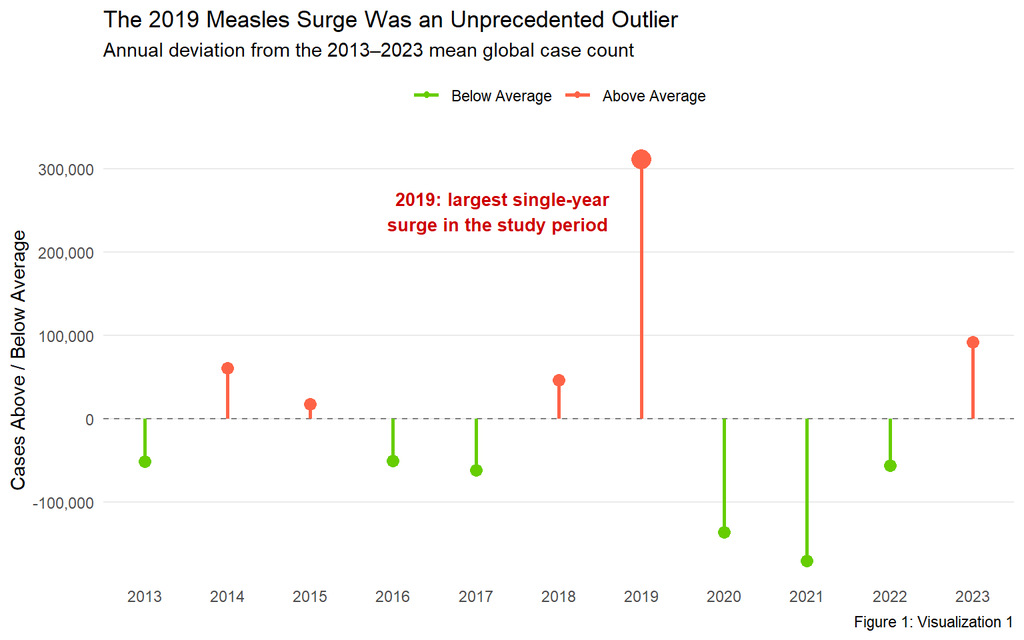

**2019** was a clear statistical outlier, with global cases far exceeding any other year in the study period. The remaining years cluster near or below the average, suggesting 2019 was not part of a broader upward trend but rather an **isolated spike**. This raises the question: Was the 2019 surge driven by outbreaks across **many countries simultaneously**, or was it **concentrated** in just a few?

**Heatmap**

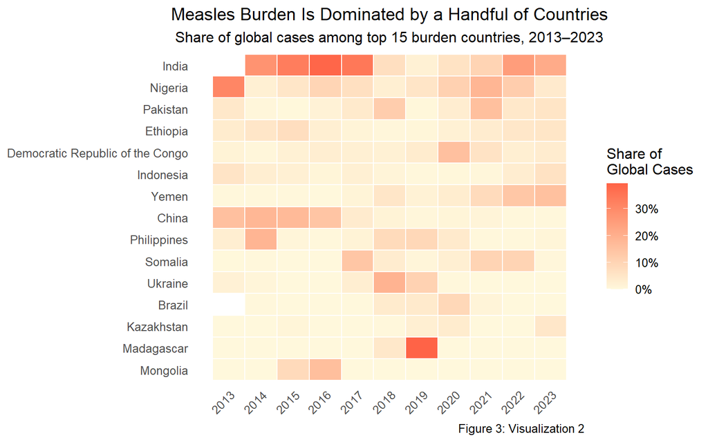

**2019 Measles Cases**

[interactive chart not shown]

Vaccination Data

Vaccination coverage data for Madagascar was obtained from the WHO Immunization Data Portal, covering the percentage of children who received the first and second doses of the measles-containing vaccine from 2000–2025, reported annually through the WHO/UNICEF Joint Reporting Form on Immunization. Official estimates reflect national authority assessments of the most likely coverage, drawing from administrative data, surveys, or other sources.

Why this country?

Madagascar made up nearly 40 percent of all measles cases reported worldwide in 2019, becoming the largest single source of that year’s global surge. With a population of roughly 30 million, this spike was not the result of a large population but a true nationwide health emergency. It also makes Madagascar an important example for understanding how vaccination coverage influences the risk of major outbreaks.

Animated Plot

The animation traces Madagascar’s measles vaccination coverage from 2000 to 2024, showing how first-dose coverage fluctuated over time and how the introduction of a second dose in 2020 followed the country’s devastating 2019 outbreak.

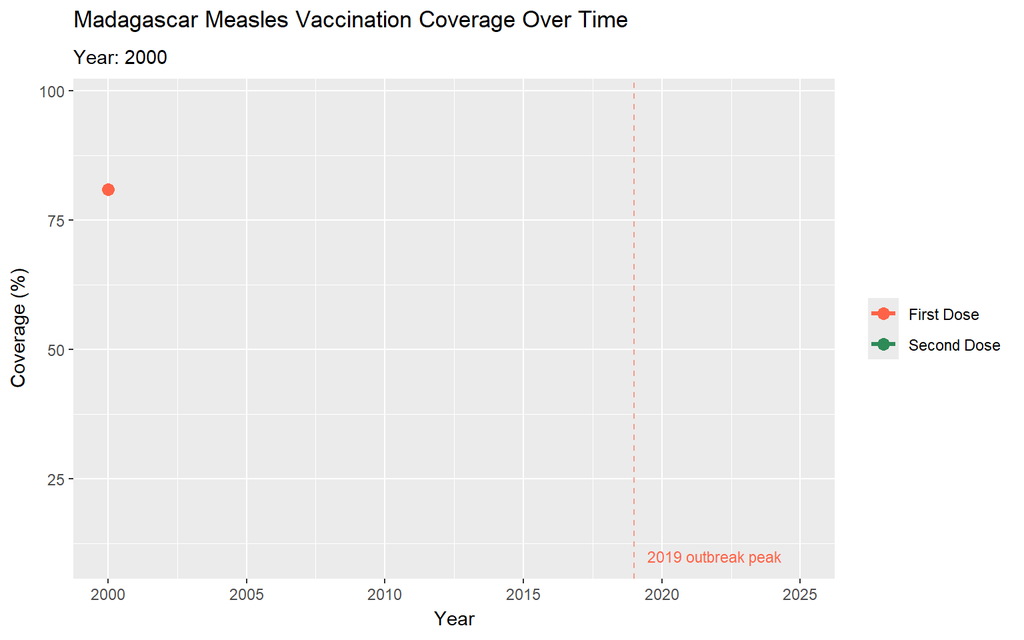